# 306.3. Cross-match by coordinate

For the Rubin Science Platform at data.lsst.cloud.  
Data Release: [Data Preview 1](https://dp1.lsst.io/)  
Container Size: large  
LSST Science Pipelines version: r29.2.0  
Last verified to run: 2025-09-02  
Repository: github.com/lsst/tutorial-notebooks

**Learning objective:** An efficient way to execute queries to check if lightcurves exist for a set of coordinates.

**LSST data products:** `DiaObject`, `ForcedSourceOnDiaObject`

**Credit:** Originally developed by the Rubin Community Science team. Please consider acknowledging them if this notebook is used for the preparation of journal articles, software releases, or other notebooks.

**Get Support:** Everyone is encouraged to ask questions or raise issues in the [Support Category](https://community.lsst.org/c/support) of the Rubin Community Forum. Rubin staff will respond to all questions posted there.

## 1. Introduction

This tutorial demonstrates how to make efficient queries for the common question of "does LSST have light curves at these sky coordinates?"

**Avoid: querying the forced photometry tables by coordinate.**

It is recommended that the fluxes in the forced photometry table, `ForcedSourceOnDiaObject`, be used to generate light curves. However, queries *by coordinate* on the `ForcedSourceOnDiaObject` table are very inefficient and should be avoided. This is because the `ForcedSourceOnDiaObject` table contains forced flux measurements made on every difference and direct image, at the location of every `DiaObject`. It is much more efficient to do the spatial cross-match with `DiaObject` once and then retrieve forced fluxes for successful matches based on their IDs, rather than spatially cross-matching to the tens or hundreds (and in the future, thousands) of visits. The same advice applies to the `ForcedSource` and `Object` tables.

**Avoid: putting asynchronous queries into `for` loops.**

Although it is possible loop over a set of RA and Dec, and make a spatial cross-match query for each coordinate, this should be avoided. In the future users will be rate-limited on TAP queries and unable to have many queries executing simultaneously.

**Correct: upload a table of coordinates and cross-match using a TAP table join.**

This notebook demonstrates how to upload a table of coordinates and use the TAP service to cross-match to the `DiaObject` table and then retrieve light curves for successful cross-matches.

**Related tutorials**: The 200-level tutorials on the `DiaObject` and `ForcedSourceOnDiaObject` catalogs. The 100-level tutorials on catalog access with TAP and ADQL query statements.

### 1.1. Import packages

Import modules from `matplotlib`, `numpy`, and `astropy`.

From the `lsst` package, import the module `get_tap_service` for accessing the Table Access Protocol (TAP) service.

```python
import matplotlib.pyplot as plt
import numpy as np
from astropy.table import Table
from lsst.rsp import get_tap_service
from lsst.utils.plotting import (get_multiband_plot_colors,
                                 get_multiband_plot_symbols)
```

### 1.2. Define parameters and functions

Create an instance of the TAP service, and assert that it exists.

```python
service = get_tap_service("tap")
assert service is not None
```

Define filter names, plot markers, linestyles, and colors for plotting

```python
filter_names = ['u', 'g', 'r', 'i', 'z', 'y']
filter_colors = get_multiband_plot_colors()
filter_symbols = get_multiband_plot_symbols()
```

## 2. Load a coordinate list

This pre-made demo list includes the `DiaObjects` identified in another tutorial in this series as being potential supernovae, and stars which may or may not be variable, all in the Extended Chandra Deep Field South (ECDFS).

The central coordinates of ECDFS are RA, Dec = 53.13, -28.10 degrees.

```python
ra_cen = 53.13
dec_cen = -28.10
```

Read in the targets as an `Astropy` `Table`.

```python
path = '/rubin/cst_repos/tutorial-notebooks-data/data/'
user_table = Table.read(path + 'dp1_306_3_targets.dat', format='ascii.csv')
assert len(user_table) == 32
```

Option to view the table.

```python
# user_table
```

Visualize the target coordinates.

Targets have been "named" with integers that represent their origin:

- 100s: known `DiaObjects`
- 200s: known `Objects` (random stars)
- 300s: random coordinates

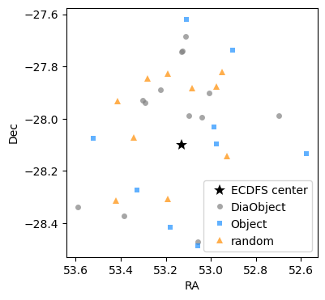

```python
fig = plt.figure(figsize=(4, 4))
plt.plot(ra_cen, dec_cen, '*', ms=10, mew=0, color='black', label='ECDFS center')
tx1 = np.where(user_table['name'] < 200)[0]
tx2 = np.where((user_table['name'] >= 200) & (user_table['name'] < 300))[0]
tx3 = np.where(user_table['name'] >= 300)[0]
plt.plot(user_table['ra'][tx1], user_table['dec'][tx1], 'o', ms=5, mew=0, alpha=0.7,
         color='grey', label='DiaObject')
plt.plot(user_table['ra'][tx2], user_table['dec'][tx2], 's', ms=5, mew=0, alpha=0.7,
         color='dodgerblue', label='Object')
plt.plot(user_table['ra'][tx3], user_table['dec'][tx3], '^', ms=6, mew=0, alpha=0.7,
         color='darkorange', label='random')
plt.legend(loc='best', handletextpad=0)
plt.gca().invert_xaxis()
plt.xlabel('RA')
plt.ylabel('Dec')
plt.show()
```

> **Figure 1**: The sky locations of the coordinates for this demonstration.

## 3. Query in two steps

### 3.1. Cross-match to diaObject

Upload the table to the TAP service and join it with the `DiaObject` table.

Use a spatial cross-match radius of 0.5 arcsec (0.00014 deg), and impose the constraint that only matched `DiaObjects` that were detected more than 10 times are returned (`nDiaSources` > 10).

Also return the `DISTANCE()`, the radial distance in degrees, between the target and the `DiaObject`. In this scenario, all matches to the `DiaObject` table are exact matches to known `DiaObjects`, so all distances will be 0.0, but in other scenarios it would be informative.

```python
query = """
        SELECT diao.diaObjectId, diao.ra, diao.dec, diao.nDiaSources,
        ut.name AS ut_name, ut.ra AS ut_ra, ut.dec AS ut_dec,
        DISTANCE(POINT('ICRS', diao.ra, diao.dec), POINT('ICRS', ut.ra, ut.dec)) AS distance
        FROM dp1.DiaObject AS diao
        JOIN TAP_UPLOAD.ut AS ut
        WHERE CONTAINS(POINT('ICRS', diao.ra, diao.dec),
        CIRCLE('ICRS', ut.ra, ut.dec, 0.00014))=1
        AND diao.nDiaSources > 10
        """
```

```python
job = service.submit_job(query, uploads={"ut": user_table})
job.run()
job.wait(phases=['COMPLETED', 'ERROR'])
print('Job phase is', job.phase)
if job.phase == 'ERROR':
    job.raise_if_error()
```

```
Job phase is COMPLETED
```

```python
assert job.phase == 'COMPLETED'
dia_objects = job.fetch_result().to_table()
```

Show the table of the 13 matched `DiaObjects`.

```python
assert len(dia_objects) == 13
print(len(dia_objects))
dia_objects
```

```
13
```

*Table length=13*

| diaObjectId int64 | ra deg float64 | dec deg float64 | nDiaSources int64 | ut_name int64 | ut_ra float64 | ut_dec float64 | distance float64 |
| --- | --- | --- | --- | --- | --- | --- | --- |
| 611255278800732178 | 52.69695529429179 | -27.988292690356108 | 78 | 108 | 52.69695529429179 | -27.988292690356108 | 0.0 |
| 609788942606139423 | 53.057543091666545 | -28.470666917705937 | 30 | 107 | 53.057543091666545 | -28.470666917705937 | 0.0 |
| 611256447031836758 | 53.11255514455679 | -27.68482288916528 | 183 | 103 | 53.11255514455679 | -27.68482288916528 | 0.0 |
| 611255759837069429 | 53.13130494487106 | -27.743080378923775 | 21 | 110 | 53.13130494487106 | -27.743080378923775 | 0.0 |
| 611255759837069401 | 53.124767650110215 | -27.739814591611168 | 253 | 102 | 53.124767650110215 | -27.739814591611168 | 0.0 |
| 611255003922825298 | 53.290560409754 | -27.937289443173917 | 52 | 113 | 53.290560409754 | -27.937289443173917 | 0.0 |
| 611255003922825270 | 53.30261321636857 | -27.93106467624108 | 37 | 112 | 53.30261321636857 | -27.93106467624108 | 0.0 |
| 611255141361779352 | 53.04016935490686 | -27.993923912026723 | 35 | 101 | 53.04016935490686 | -27.993923912026723 | 0.0 |
| 611255141361779062 | 53.007957021858076 | -27.902674310446752 | 36 | 106 | 53.007957021858076 | -27.902674310446752 | 0.0 |
| 611255072642302059 | 53.2226933114704 | -27.889567374680585 | 37 | 105 | 53.2226933114704 | -27.889567374680585 | 0.0 |
| 611255072642301958 | 53.097942739683255 | -27.986920270662733 | 109 | 111 | 53.097942739683255 | -27.986920270662733 | 0.0 |
| 609789423642476567 | 53.59070920538382 | -28.337607282878942 | 38 | 109 | 53.59070920538382 | -28.337607282878942 | 0.0 |
| 609788805167185927 | 53.38674314387356 | -28.372341661331774 | 167 | 104 | 53.38674314387356 | -28.372341661331774 | 0.0 |

The table above shows that only known `DiaObjects` (with a `ut_name` starting with the number 1) were successfully cross matched, as expected.

Confirm that no targets were matched with multiple `DiaObjects`.

```python
values, counts = np.unique(dia_objects['ut_name'], return_counts=True)
tx = np.where(counts > 1)[0]
print('Number of multiply-matched targets: ', len(tx))
```

```
Number of multiply-matched targets:  0
```

### 3.2. Retrieve forced photometry

Retrieve forced photometry by `diaObjectId` using a `WHERE ... IN ()` statement.

```python
dia_object_id_list = "(" + ", ".join(str(value) for value in dia_objects['diaObjectId']) + ")"
print(dia_object_id_list)
```

```
(611255278800732178, 609788942606139423, 611256447031836758, 611255759837069429, 611255759837069401, 611255003922825298, 611255003922825270, 611255141361779352, 611255141361779062, 611255072642302059, 611255072642301958, 609789423642476567, 609788805167185927)
```

```python
query = """SELECT fsodo.coord_ra, fsodo.coord_dec,
        fsodo.diaObjectId, fsodo.visit, fsodo.band,
        fsodo.psfDiffFlux, fsodo.psfDiffFluxErr,
        vis.expMidptMJD
        FROM dp1.ForcedSourceOnDiaObject as fsodo
        JOIN dp1.Visit as vis ON vis.visit = fsodo.visit
        WHERE diaObjectId IN {}
        ORDER BY diaObjectId ASC
        """.format(dia_object_id_list)
```

```python
job = service.submit_job(query)
job.run()
job.wait(phases=['COMPLETED', 'ERROR'])
print('Job phase is', job.phase)
if job.phase == 'ERROR':
    job.raise_if_error()
```

```
Job phase is COMPLETED
```

```python
assert job.phase == 'COMPLETED'
fsodo_table = job.fetch_result().to_table()
```

```python
assert len(fsodo_table) == 7034
print(len(fsodo_table))
```

```
7034
```

Option to display the table of forced photometry.

```python
# fsodo_table
```

See Section 5 for a demonstration of how to plot light curves using the retrieved forced photometry.

```python
del dia_objects, fsodo_table
```

## 4. Query in one step (table join)

Combine the two steps of Section 3 into a single query with table joins.

This query does the spatial cross-match to the targets on the `DiaObject` table, and joins with the `ForcedSourceOnDiaObject` and `Visit` table to retrieve light curves for successful matches.

```python
query = """
        SELECT diao.diaObjectId, diao.ra, diao.dec, diao.nDiaSources,
        ut.name AS ut_name, ut.ra AS ut_ra, ut.dec AS ut_dec,
        fsodo.diaObjectId, fsodo.visit, fsodo.band,
        fsodo.psfDiffFlux, fsodo.psfDiffFluxErr,
        v.expMidptMJD
        FROM dp1.DiaObject AS diao
        JOIN TAP_UPLOAD.ut AS ut
        JOIN dp1.ForcedSourceOnDiaObject AS fsodo ON fsodo.diaObjectId = diao.diaObjectId
        JOIN dp1.Visit AS v ON v.visit = fsodo.visit
        WHERE CONTAINS(POINT('ICRS', diao.ra, diao.dec),
        CIRCLE('ICRS', ut.ra, ut.dec, 0.00014))=1
        AND diao.nDiaSources > 10
        """
print(query)
```

```
        SELECT diao.diaObjectId, diao.ra, diao.dec, diao.nDiaSources,
        ut.name AS ut_name, ut.ra AS ut_ra, ut.dec AS ut_dec,
        fsodo.diaObjectId, fsodo.visit, fsodo.band,
        fsodo.psfDiffFlux, fsodo.psfDiffFluxErr,
        v.expMidptMJD
        FROM dp1.DiaObject AS diao
        JOIN TAP_UPLOAD.ut AS ut
        JOIN dp1.ForcedSourceOnDiaObject AS fsodo ON fsodo.diaObjectId = diao.diaObjectId
        JOIN dp1.Visit AS v ON v.visit = fsodo.visit
        WHERE CONTAINS(POINT('ICRS', diao.ra, diao.dec),
        CIRCLE('ICRS', ut.ra, ut.dec, 0.00014))=1
        AND diao.nDiaSources > 10
```

```python
job = service.submit_job(query, uploads={"ut": user_table})
job.run()
job.wait(phases=['COMPLETED', 'ERROR'])
print('Job phase is', job.phase)
if job.phase == 'ERROR':
    job.raise_if_error()
```

```
Job phase is COMPLETED
```

```python
assert job.phase == 'COMPLETED'
fsodo_table_2 = job.fetch_result().to_table()
```

```python
assert len(fsodo_table_2) == 7034
print(len(fsodo_table_2))
```

```
7034
```

The `fsodo_table_2` table contains the same data as the `fsodo_table` from Section 3.2.

## 5. Plot light curves

How to plot light curves is also demonstrated in other tutorials.

First get the identifiers of the unique `DiaObjects` for which forced photometry was returned.

```python
unique_dia_obj_id = np.unique(fsodo_table_2['diaObjectId'])
assert len(unique_dia_obj_id) == 13
print(len(unique_dia_obj_id))
```

```
13
```

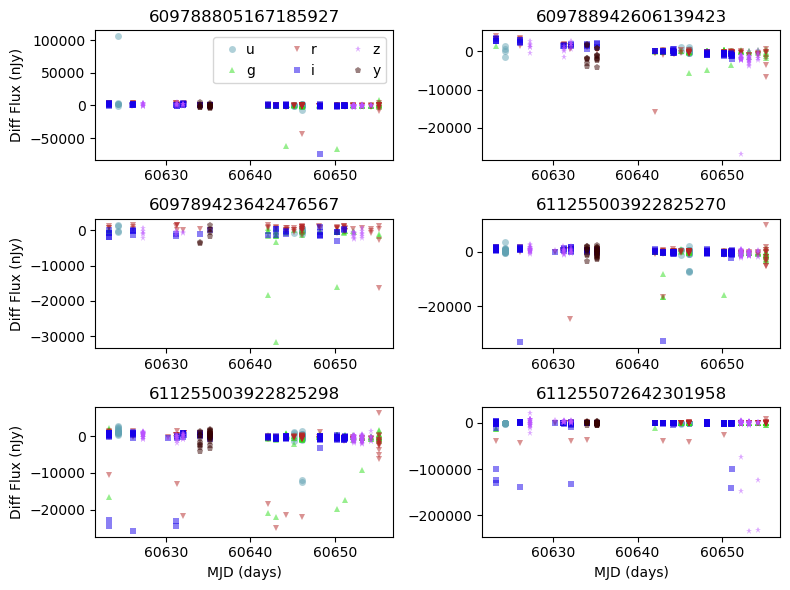

```python
fig, ax = plt.subplots(3, 2, figsize=(8, 6), sharey=False, sharex=False)
x = 0
for i in range(3):
    for j in range(2):
        for f, filt in enumerate(filter_names):
            dx = np.where(fsodo_table_2['diaObjectId'] == unique_dia_obj_id[x])
            lc = fsodo_table_2[dx]
            fx = np.where(lc['band'] == filt)[0]
            if (i == 0) & (j == 0):
                ax[i, j].plot(lc['expMidptMJD'][fx], lc['psfDiffFlux'][fx],
                              filter_symbols[filt], ms=5, mew=0, alpha=0.5,
                              color=filter_colors[filt], label=filt)
            else:
                ax[i, j].plot(lc['expMidptMJD'][fx], lc['psfDiffFlux'][fx],
                              filter_symbols[filt], ms=5, mew=0, alpha=0.5,
                              color=filter_colors[filt])
            del dx, fx
        ax[i, j].set_title(unique_dia_obj_id[x])
        del lc
        if (i == 0) & (j == 0):
            ax[i, j].legend(loc='best', ncol=3, handletextpad=0)
        if i == 2:
            ax[i, j].xaxis.set_label_text('MJD (days)')
        if j == 0:
            ax[i, j].yaxis.set_label_text('Diff Flux (nJy)')
        x += 1
plt.tight_layout()
plt.show()
```

> **Figure 2**: The first six light curves.

```python
del fsodo_table_2
```